# Future Spread Characterization

### Data Calculation, Analysis and Visualization

In the homework spread is defined as follows\ $\text{Spread between ICE Brent crude oil versus ICE Gas Oil at time t} := s_{1}^{t} = \text{ICE\_B\_B} - 0.1147 * \text{ICE\_G\_G}$ \ $\text{Spread between CBT five year US T-Notes versus CBT thirty year US T-Bonds at time t} := s_{2}^{t} = \text{CBT\_FV\_FV} - 0.7595 * \text{CBT\_US\_US}$

For either future pair $i$, the following time series will be calculated and included in a merged dataframe. $\text{Daily return on spread at time t} := r_{t, \text{CBT}} = \frac{s_{i}^{t} - s_{i}^{t-1}}{s_{i}^{t-1}}$ \ $\text{Rolling average of spread at time t over N days} := \overline{s}_{i, N}^{t} = \frac{1}{N}\sum_{i=1}^{N}s_{i}^{i}$ \ $\text{Difference between spread and rolling average at time t over N days} := d_{i, N} = \overline{s}_{i, N}^{t} - s_{i}^{t}$ \ $\text{Standard deviation of the difference between spread and rolling average at time t over N days} := \text{std}(d_{i, N})$

```python
merged_df_cbt = pd.merge(df_FV, df_US, left_index= True, right_index= True, how='inner')
merged_df_cbt['Spread (CBT)'] = merged_df_cbt['CBT_FV_FV Future'] - 0.7595 * merged_df_cbt['CBT_US_US Future']
merged_df_cbt['Return on spread (CBT)'] = merged_df_cbt['Spread (CBT)'].pct_change()
merged_df_cbt['Rolling Avg 20 days (CBT)'] = merged_df_cbt['Spread (CBT)'].rolling(20).mean()
merged_df_cbt['Rolling Avg 50 days (CBT)'] = merged_df_cbt['Spread (CBT)'].rolling(50).mean()
merged_df_cbt['Rolling Avg 100 days (CBT)'] = merged_df_cbt['Spread (CBT)'].rolling(100).mean()
merged_df_cbt['Rolling Avg 20 days - Spread (CBT)'] = merged_df_cbt['Rolling Avg 20 days (CBT)']- merged_df_cbt['Spread (CBT)']
merged_df_cbt['Rolling Avg 50 days - Spread (CBT)'] = merged_df_cbt['Rolling Avg 50 days (CBT)'] -  merged_df_cbt['Spread (CBT)']
merged_df_cbt['Rolling Avg 100 days - Spread (CBT)'] = merged_df_cbt['Rolling Avg 100 days (CBT)'] - merged_df_cbt['Spread (CBT)']
merged_df_cbt['Rollig sigma 20 days (CBT)'] = merged_df_cbt['Rolling Avg 20 days - Spread (CBT)'].rolling(20).std()
merged_df_cbt['Rollig sigma 50 days (CBT)'] = merged_df_cbt['Rolling Avg 50 days - Spread (CBT)'].rolling(50).std()
merged_df_cbt['Rollig sigma 100 days (CBT)'] = merged_df_cbt['Rolling Avg 100 days - Spread (CBT)'].rolling(100).std()
merged_df_cbt['Normalized 5-year price (CBT)'] = 100 * merged_df_cbt['CBT_FV_FV Future'] / merged_df_cbt['CBT_FV_FV Future'].iloc[0]
merged_df_cbt['Normalized 30-year price (CBT)'] = 100 * merged_df_cbt['CBT_US_US Future'] / merged_df_cbt['CBT_US_US Future'].iloc[0]
merged_df_cbt
```

|  | CBT_FV_FV Future | CBT_US_US Future | Spread (CBT) | Return on spread (CBT) | Rolling Avg 20 days (CBT) | Rolling Avg 50 days (CBT) | Rolling Avg 100 days (CBT) | Rolling Avg 20 days - Spread (CBT) | Rolling Avg 50 days - Spread (CBT) | Rolling Avg 100 days - Spread (CBT) | Rollig sigma 20 days (CBT) | Rollig sigma 50 days (CBT) | Rollig sigma 100 days (CBT) | Normalized 5-year price (CBT) | Normalized 30-year price (CBT) |
| --- | --- | --- | --- | --- | --- | --- | --- | --- | --- | --- | --- | --- | --- | --- | --- |
| 2020-12-03 | 125.820312 | 172.87500 | -5.478250 | NaN | NaN | NaN | NaN | NaN | NaN | NaN | NaN | NaN | NaN | 100.000000 | 100.000000 |
| 2020-12-04 | 125.734375 | 171.65625 | -4.638547 | -0.153279 | NaN | NaN | NaN | NaN | NaN | NaN | NaN | NaN | NaN | 99.931698 | 99.295011 |
| 2020-12-07 | 125.898438 | 172.53125 | -5.139047 | 0.107900 | NaN | NaN | NaN | NaN | NaN | NaN | NaN | NaN | NaN | 100.062093 | 99.801157 |
| 2020-12-08 | 125.906250 | 173.06250 | -5.534719 | 0.076993 | NaN | NaN | NaN | NaN | NaN | NaN | NaN | NaN | NaN | 100.068302 | 100.108460 |
| 2020-12-09 | 125.812500 | 172.46875 | -5.177516 | -0.064539 | NaN | NaN | NaN | NaN | NaN | NaN | NaN | NaN | NaN | 99.993791 | 99.765004 |
| ... | ... | ... | ... | ... | ... | ... | ... | ... | ... | ... | ... | ... | ... | ... | ... |
| 2022-11-14 | 107.687500 | 123.65625 | 13.770578 | -0.000459 | 14.711348 | 12.295727 | 9.222021 | 0.940770 | -1.474851 | -4.548557 | 1.281387 | 0.890993 | 2.534763 | 85.588327 | 71.529284 |
| 2022-11-15 | 108.015625 | 124.53125 | 13.434141 | -0.024432 | 14.741748 | 12.372854 | 9.272484 | 1.307607 | -1.061287 | -4.161657 | 1.415934 | 0.958733 | 2.535819 | 85.849115 | 72.035430 |
| 2022-11-16 | 108.289062 | 126.40625 | 12.283516 | -0.085649 | 14.681407 | 12.437825 | 9.319891 | 2.397891 | 0.154310 | -2.963625 | 1.625674 | 1.086901 | 2.535559 | 86.066439 | 73.120029 |
| 2022-11-17 | 107.882812 | 125.84375 | 12.304484 | 0.001707 | 14.587042 | 12.500957 | 9.373292 | 2.282558 | 0.196473 | -2.931192 | 1.755284 | 1.201627 | 2.535901 | 85.743558 | 72.794649 |
| 2022-11-18 | 107.632812 | 125.43750 | 12.363031 | 0.004758 | 14.421544 | 12.564726 | 9.426879 | 2.058513 | 0.201695 | -2.936152 | 1.745697 | 1.303485 | 2.536240 | 85.544862 | 72.559653 |

511 rows × 15 columns

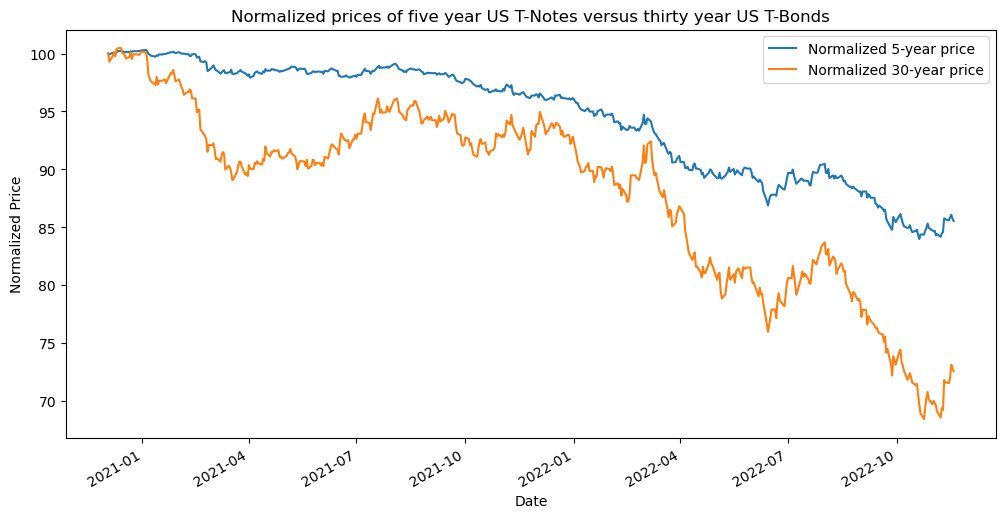

```python
merged_df_cbt.plot(y = ['Normalized 5-year price', 'Normalized 30-year price'], figsize=(12, 6))
plt.xlabel('Date')
plt.ylabel('Normalized Price')
plt.title('Normalized prices of five year US T-Notes versus thirty year US T-Bonds')
```

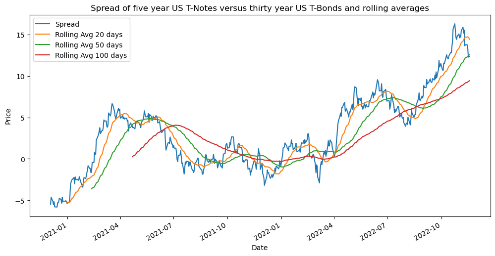

```python
merged_df_cbt.plot(y = ['Spread', 'Rolling Avg 20 days', 'Rolling Avg 50 days', 'Rolling Avg 100 days'], figsize=(12, 6))
plt.xlabel('Date')
plt.ylabel('Price')
plt.title('Spread of five year US T-Notes versus thirty year US T-Bonds and rolling averages')
```

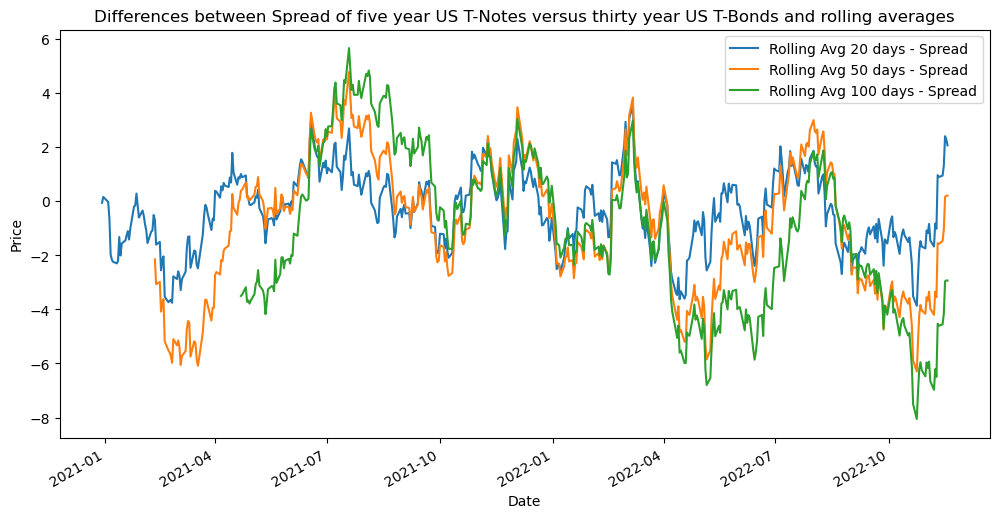

```python
merged_df_cbt.plot(y = ['Rolling Avg 20 days - Spread', 'Rolling Avg 50 days - Spread', 'Rolling Avg 100 days - Spread'], figsize=(12, 6))
plt.xlabel('Date')
plt.ylabel('Price')
plt.title('Differences between Spread of five year US T-Notes versus thirty year US T-Bonds and rolling averages')
```

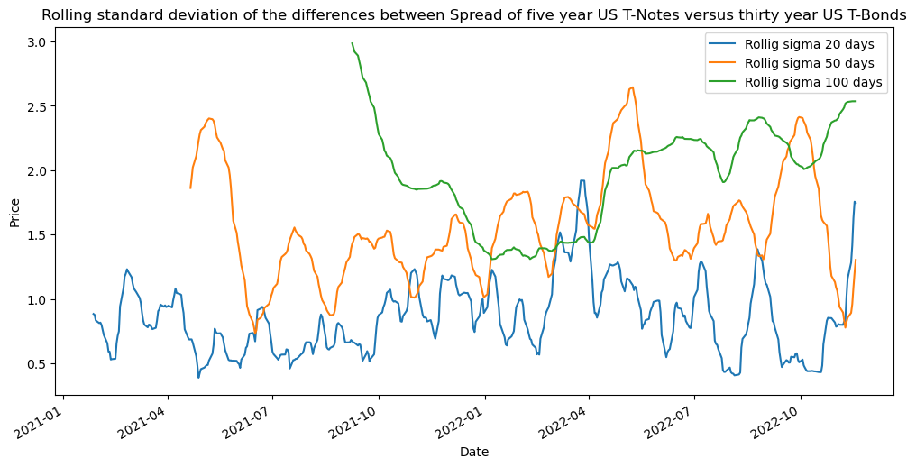

```python
merged_df_cbt.plot(y = ['Rollig sigma 20 days', 'Rollig sigma 50 days', 'Rollig sigma 100 days'], figsize=(12, 6))
plt.xlabel('Date')
plt.ylabel('Price')
plt.title('Rolling standard deviation of the differences between Spread of five year US T-Notes versus thirty year US T-Bonds')
```

```python
def performance_summary(return_data):
    """
        Returns the Performance Stats for given set of returns
        Inputs:
            return_data - DataFrame with Date index and Monthly Returns for different assets/strategies.
        Output:
            summary_stats - DataFrame with annualized mean return, vol, sharpe ratio. Skewness, Excess Kurtosis, Var (0.5) and
                            CVaR (0.5) and drawdown based on monthly returns.
    """
    summary_stats = return_data.mean().to_frame('Mean').apply(lambda x: x*12)
    summary_stats['Volatility'] = return_data.std().apply(lambda x: x*np.sqrt(12))
    summary_stats['Sharpe Ratio'] = summary_stats['Mean']/summary_stats['Volatility']

    summary_stats['Skewness'] = return_data.skew()
    summary_stats['Excess Kurtosis'] = return_data.kurtosis()
    summary_stats['VaR (0.05)'] = return_data.quantile(.05, axis = 0)
    summary_stats['CVaR (0.05)'] = return_data[return_data <= return_data.quantile(.05, axis = 0)].mean()
    summary_stats['Min'] = return_data.min()
    summary_stats['Max'] = return_data.max()

    wealth_index = 1000*(1+return_data).cumprod()
    previous_peaks = wealth_index.cummax()
    drawdowns = (wealth_index - previous_peaks)/previous_peaks

    summary_stats['Max Drawdown'] = drawdowns.min()
    summary_stats['Peak'] = [previous_peaks[col][:drawdowns[col].idxmin()].idxmax() for col in previous_peaks.columns]
    summary_stats['Bottom'] = drawdowns.idxmin()

    recovery_date = []
    for col in wealth_index.columns:
        prev_max = previous_peaks[col][:drawdowns[col].idxmin()].max()
        recovery_wealth = pd.DataFrame([wealth_index[col][drawdowns[col].idxmin():]]).T
        recovery_date.append(recovery_wealth[recovery_wealth[col] >= prev_max].index.min())
    summary_stats['Recovery'] = recovery_date

    return summary_stats
```

```python
merged_df_ice = pd.merge(df_BB, df_GG, left_index= True, right_index= True, how='inner')
merged_df_ice['Spread (ICE)'] = merged_df_ice['ICE_B_B Future'] - 0.1147 * merged_df_ice['ICE_G_G Future']
merged_df_ice['Return on spread (ICE)'] = merged_df_ice['Spread (ICE)'].pct_change()
merged_df_ice['Rolling Avg 20 days (ICE)'] = merged_df_ice['Spread (ICE)'].rolling(20).mean()
merged_df_ice['Rolling Avg 50 days (ICE)'] = merged_df_ice['Spread (ICE)'].rolling(50).mean()
merged_df_ice['Rolling Avg 100 days (ICE)'] = merged_df_ice['Spread (ICE)'].rolling(100).mean()
merged_df_ice['Rolling Avg 20 days - Spread (ICE)'] = merged_df_ice['Rolling Avg 20 days (ICE)']- merged_df_ice['Spread (ICE)']
merged_df_ice['Rolling Avg 50 days - Spread (ICE)'] = merged_df_ice['Rolling Avg 50 days (ICE)'] -  merged_df_ice['Spread (ICE)']
merged_df_ice['Rolling Avg 100 days - Spread (ICE)'] = merged_df_ice['Rolling Avg 100 days (ICE)'] - merged_df_ice['Spread (ICE)']
merged_df_ice['Rollig sigma 20 days (ICE)'] = merged_df_ice['Rolling Avg 20 days - Spread (ICE)'].rolling(20).std()
merged_df_ice['Rollig sigma 50 days (ICE)'] = merged_df_ice['Rolling Avg 50 days - Spread (ICE)'].rolling(50).std()
merged_df_ice['Rollig sigma 100 days (ICE)'] = merged_df_ice['Rolling Avg 100 days - Spread (ICE)'].rolling(100).std()
merged_df_ice['Normalized Brent Crude Oil price'] = 100 * merged_df_ice['ICE_B_B Future'] / merged_df_ice['ICE_B_B Future'].iloc[0]
merged_df_ice['Normalized Gas Oil price'] = 100 * merged_df_ice['ICE_G_G Future'] / merged_df_ice['ICE_G_G Future'].iloc[0]
merged_df_ice
```

|  | ICE_B_B Future | ICE_G_G Future | Spread (ICE) | Return on spread (ICE) | Rolling Avg 20 days (ICE) | Rolling Avg 50 days (ICE) | Rolling Avg 100 days (ICE) | Rolling Avg 20 days - Spread (ICE) | Rolling Avg 50 days - Spread (ICE) | Rolling Avg 100 days - Spread (ICE) | Rollig sigma 20 days (ICE) | Rollig sigma 50 days (ICE) | Rollig sigma 100 days (ICE) | Normalized Brent Crude Oil price | Normalized Gas Oil price |
| --- | --- | --- | --- | --- | --- | --- | --- | --- | --- | --- | --- | --- | --- | --- | --- |
| 2020-12-03 | 48.60 | 404.75 | 2.175175 | NaN | NaN | NaN | NaN | NaN | NaN | NaN | NaN | NaN | NaN | 100.000000 | 100.000000 |
| 2020-12-04 | 49.19 | 406.00 | 2.621800 | 0.205328 | NaN | NaN | NaN | NaN | NaN | NaN | NaN | NaN | NaN | 101.213992 | 100.308833 |
| 2020-12-07 | 48.80 | 410.00 | 1.773000 | -0.323747 | NaN | NaN | NaN | NaN | NaN | NaN | NaN | NaN | NaN | 100.411523 | 101.297097 |
| 2020-12-08 | 48.81 | 409.75 | 1.811675 | 0.021813 | NaN | NaN | NaN | NaN | NaN | NaN | NaN | NaN | NaN | 100.432099 | 101.235330 |
| 2020-12-09 | 48.77 | 406.75 | 2.115775 | 0.167856 | NaN | NaN | NaN | NaN | NaN | NaN | NaN | NaN | NaN | 100.349794 | 100.494132 |
| ... | ... | ... | ... | ... | ... | ... | ... | ... | ... | ... | ... | ... | ... | ... | ... |
| 2022-09-26 | 82.86 | 871.00 | -17.043700 | -0.043951 | -18.821926 | -20.717237 | -20.730822 | -1.778226 | -3.673537 | -3.687122 | 3.273160 | 3.627632 | 7.343729 | 170.493827 | 215.194565 |
| 2022-09-27 | 84.87 | 890.00 | -17.213000 | 0.009933 | -18.654442 | -20.604118 | -20.683972 | -1.441443 | -3.391118 | -3.470972 | 3.259093 | 3.568729 | 7.330753 | 174.629630 | 219.888820 |
| 2022-09-28 | 88.05 | 920.75 | -17.560025 | 0.020161 | -18.482136 | -20.487510 | -20.733945 | -0.922111 | -2.927485 | -3.173920 | 3.238471 | 3.495262 | 7.384132 | 181.172840 | 227.486103 |
| 2022-09-29 | 87.18 | 922.50 | -18.630750 | 0.060975 | -18.482676 | -20.448773 | -20.804943 | 0.148074 | -1.818023 | -2.174193 | 3.284492 | 3.484516 | 7.425413 | 179.382716 | 227.918468 |
| 2022-09-30 | 85.14 | 902.25 | -18.348075 | -0.015172 | -18.357376 | -20.299304 | -20.887842 | -0.009301 | -1.951230 | -2.539767 | 3.290610 | 3.334573 | 7.467805 | 175.185185 | 222.915380 |

472 rows × 15 columns

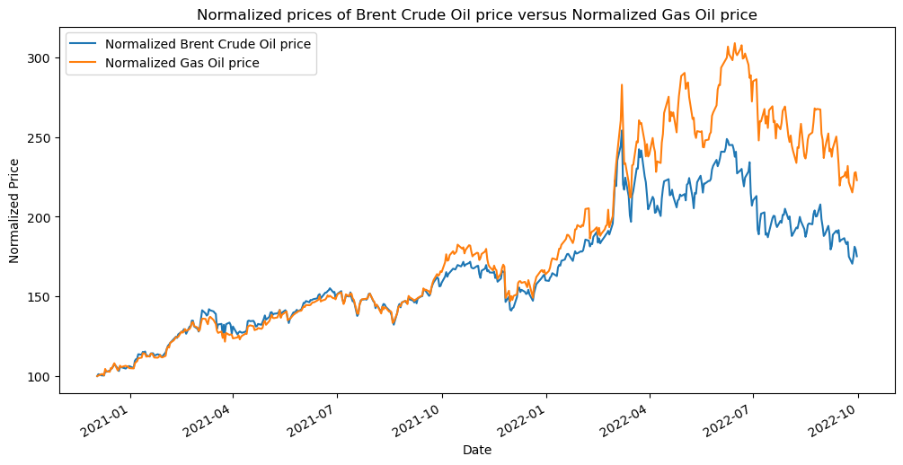

```python
merged_df_ice.plot(y = ['Normalized Brent Crude Oil price', 'Normalized Gas Oil price'], figsize=(12, 6))
plt.xlabel('Date')
plt.ylabel('Normalized Price')
plt.title('Normalized prices of Brent Crude Oil price versus Normalized Gas Oil price')
```

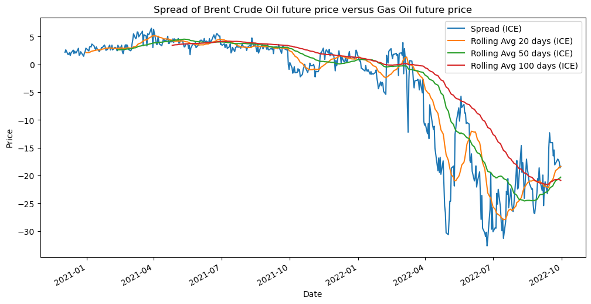

```python
merged_df_ice.plot(y = ['Spread (ICE)','Rolling Avg 20 days (ICE)',
       'Rolling Avg 50 days (ICE)', 'Rolling Avg 100 days (ICE)'], figsize=(12, 6))
plt.xlabel('Date')
plt.ylabel('Price')
plt.title('Spread of Brent Crude Oil future price versus Gas Oil future price')
```

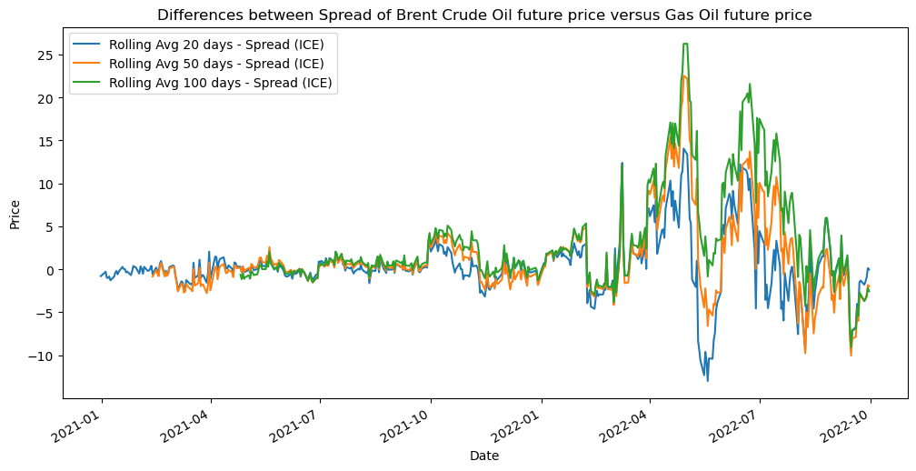

```python
merged_df_ice.plot(y = ['Rolling Avg 20 days - Spread (ICE)',
       'Rolling Avg 50 days - Spread (ICE)',
       'Rolling Avg 100 days - Spread (ICE)'], figsize=(12, 6))
plt.xlabel('Date')
plt.ylabel('Price')
plt.title('Differences between Spread of Brent Crude Oil future price versus Gas Oil future price')
```

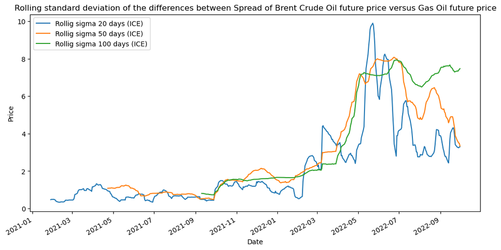

```python
merged_df_ice.plot(y = ['Rollig sigma 20 days (ICE)',
       'Rollig sigma 50 days (ICE)', 'Rollig sigma 100 days (ICE)'], figsize=(12, 6))
plt.xlabel('Date')
plt.ylabel('Price')
plt.title('Rolling standard deviation of the differences between Spread of Brent Crude Oil future price versus Gas Oil future price')
```

### Summary Statistics Analysis

```python
(performance_summary(merged_df_cbt[['CBT_FV_FV Future', 'CBT_US_US Future', 'Spread (CBT)', 'Return on spread (CBT)']])).round(2)
```

|  | Mean | Volatility | Sharpe Ratio | Skewness | Excess Kurtosis | VaR (0.05) | CVaR (0.05) | Min | Max | Max Drawdown | Peak | Bottom | Recovery |
| --- | --- | --- | --- | --- | --- | --- | --- | --- | --- | --- | --- | --- | --- |
| CBT_FV_FV Future | 1425.40 | 21.31 | 66.88 | -0.58 | -1.10 | 107.37 | 106.54 | 105.66 | 126.20 | 0.000000e+00 | 2020-12-03 | 2020-12-03 | 2020-12-03 |
| CBT_US_US Future | 1826.59 | 46.90 | 38.95 | -0.71 | -0.42 | 124.73 | 121.74 | 118.31 | 173.69 | 0.000000e+00 | 2020-12-03 | 2020-12-03 | 2020-12-03 |
| Spread (CBT) | 38.10 | 16.17 | 2.36 | 0.54 | -0.02 | -3.12 | -4.97 | -5.82 | 16.31 | -1.618746e+153 | 2021-07-19 | 2022-11-18 | NaT |
| Return on spread (CBT) | -0.28 | 4.27 | -0.06 | -5.33 | 71.93 | -0.74 | -2.83 | -14.77 | 7.30 | -3.800000e+00 | 2020-12-14 | 2022-10-24 | NaT |

THe volatility of the spread is small relative to the absolute value of spread. In a low volatility envrionment where the spread changes not as frequently the aforementioned mean-reversion strategy would be a good fit since spreads that deviates slightly from the mean would revert back to it more quickly. The volatility for the return on spread is, however, relatively large with respect to mean.

A look at Value-at-Risk figures for spread and its return indicate that there is 5% probability that the spread price level would go down to -3.12 and return, -0.74.

```python
(performance_summary(merged_df_ice[['ICE_B_B Future', 'ICE_G_G Future', 'Spread (ICE)', 'Return on spread (ICE)']])).round(2)
```

|  | Mean | Volatility | Sharpe Ratio | Skewness | Excess Kurtosis | VaR (0.05) | CVaR (0.05) | Min | Max | Max Drawdown | Peak | Bottom | Recovery |
| --- | --- | --- | --- | --- | --- | --- | --- | --- | --- | --- | --- | --- | --- |
| ICE_B_B Future | 969.93 | 61.08 | 15.88 | 0.33 | -0.74 | 54.25 | 50.88 | 48.60 | 123.48 | 0.00 | 2020-12-03 | 2020-12-03 | 2020-12-03 |
| ICE_G_G Future | 8890.84 | 797.79 | 11.14 | 0.54 | -1.00 | 446.62 | 423.81 | 404.75 | 1250.00 | 0.00 | 2020-12-03 | 2020-12-03 | 2020-12-03 |
| Spread (ICE) | -49.85 | 36.92 | -1.35 | -1.18 | -0.09 | -26.01 | -29.12 | -32.67 | 6.51 | -31.26 | 2022-06-23 | 2022-06-24 | 2022-06-27 |
| Return on spread (ICE) | -131.79 | 818.60 | -0.16 | -21.69 | 470.59 | -0.86 | -219.66 | -5127.50 | 25.22 | -6.02 | 2021-03-29 | 2022-06-23 | NaT |

Both future prices from ICE exchange are skewed to the right (unlike US treasuries which are skewed to the left) but other statistics are consistent with US treasuries in terms of signs as well as relative values.

### Correlation Analysis

```python
merged_df = pd.merge(merged_df_cbt, merged_df_ice, left_index=True, right_index=True, how='inner')
merged_df
```

|  | CBT_FV_FV Future | CBT_US_US Future | Spread (CBT) | Return on spread (CBT) | Rolling Avg 20 days (CBT) | Rolling Avg 50 days (CBT) | Rolling Avg 100 days (CBT) | Rolling Avg 20 days - Spread (CBT) | Rolling Avg 50 days - Spread (CBT) | Rolling Avg 100 days - Spread (CBT) | ... | Rolling Avg 50 days (ICE) | Rolling Avg 100 days (ICE) | Rolling Avg 20 days - Spread (ICE) | Rolling Avg 50 days - Spread (ICE) | Rolling Avg 100 days - Spread (ICE) | Rollig sigma 20 days (ICE) | Rollig sigma 50 days (ICE) | Rollig sigma 100 days (ICE) | Normalized Brent Crude Oil price | Normalized Gas Oil price |
| --- | --- | --- | --- | --- | --- | --- | --- | --- | --- | --- | --- | --- | --- | --- | --- | --- | --- | --- | --- | --- | --- |
| 2020-12-03 | 125.820312 | 172.87500 | -5.478250 | NaN | NaN | NaN | NaN | NaN | NaN | NaN | ... | NaN | NaN | NaN | NaN | NaN | NaN | NaN | NaN | 100.000000 | 100.000000 |
| 2020-12-04 | 125.734375 | 171.65625 | -4.638547 | -0.153279 | NaN | NaN | NaN | NaN | NaN | NaN | ... | NaN | NaN | NaN | NaN | NaN | NaN | NaN | NaN | 101.213992 | 100.308833 |
| 2020-12-07 | 125.898438 | 172.53125 | -5.139047 | 0.107900 | NaN | NaN | NaN | NaN | NaN | NaN | ... | NaN | NaN | NaN | NaN | NaN | NaN | NaN | NaN | 100.411523 | 101.297097 |
| 2020-12-08 | 125.906250 | 173.06250 | -5.534719 | 0.076993 | NaN | NaN | NaN | NaN | NaN | NaN | ... | NaN | NaN | NaN | NaN | NaN | NaN | NaN | NaN | 100.432099 | 101.235330 |
| 2020-12-09 | 125.812500 | 172.46875 | -5.177516 | -0.064539 | NaN | NaN | NaN | NaN | NaN | NaN | ... | NaN | NaN | NaN | NaN | NaN | NaN | NaN | NaN | 100.349794 | 100.494132 |
| ... | ... | ... | ... | ... | ... | ... | ... | ... | ... | ... | ... | ... | ... | ... | ... | ... | ... | ... | ... | ... | ... |
| 2022-09-26 | 106.835938 | 126.50000 | 10.759188 | 0.101387 | 9.270223 | 7.024585 | 7.130604 | -1.488964 | -3.734603 | -3.628584 | ... | -20.717237 | -20.730822 | -1.778226 | -3.673537 | -3.687122 | 3.273160 | 3.627632 | 7.343729 | 170.493827 | 215.194565 |
| 2022-09-27 | 106.679688 | 124.81250 | 11.884594 | 0.104600 | 9.497531 | 7.135478 | 7.174022 | -2.387063 | -4.749115 | -4.710572 | ... | -20.604118 | -20.683972 | -1.441443 | -3.391118 | -3.470972 | 3.259093 | 3.568729 | 7.330753 | 174.629630 | 219.888820 |
| 2022-09-28 | 108.062500 | 127.68750 | 11.083844 | -0.067377 | 9.669374 | 7.231439 | 7.215781 | -1.414470 | -3.852405 | -3.868062 | ... | -20.487510 | -20.733945 | -0.922111 | -2.927485 | -3.173920 | 3.238471 | 3.495262 | 7.384132 | 181.172840 | 227.486103 |
| 2022-09-29 | 107.773438 | 127.06250 | 11.269469 | 0.016747 | 9.790430 | 7.342713 | 7.264599 | -1.479038 | -3.926756 | -4.004869 | ... | -20.448773 | -20.804943 | 0.148074 | -1.818023 | -2.174193 | 3.284492 | 3.484516 | 7.425413 | 179.382716 | 227.918468 |
| 2022-09-30 | 107.507812 | 126.40625 | 11.502266 | 0.020657 | 9.935335 | 7.471781 | 7.306430 | -1.566930 | -4.030485 | -4.195836 | ... | -20.299304 | -20.887842 | -0.009301 | -1.951230 | -2.539767 | 3.290610 | 3.334573 | 7.467805 | 175.185185 | 222.915380 |

472 rows × 30 columns

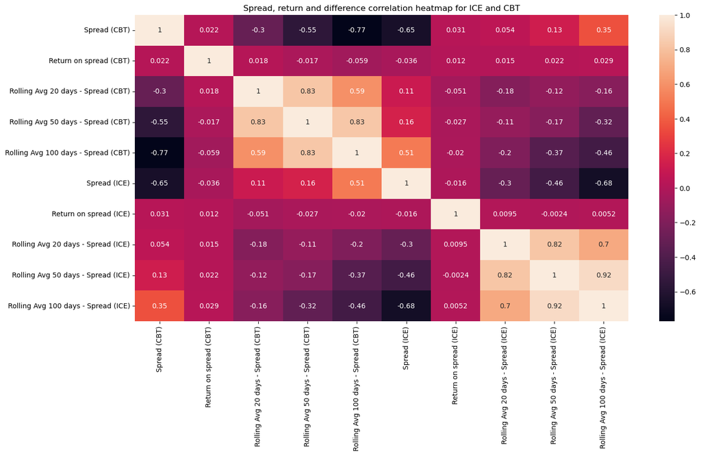

```python
corr = merged_df[['Spread (CBT)', 'Return on spread (CBT)', 'Rolling Avg 20 days - Spread (CBT)',
       'Rolling Avg 50 days - Spread (CBT)',
       'Rolling Avg 100 days - Spread (CBT)', 'Spread (ICE)',
       'Return on spread (ICE)',
       'Rolling Avg 20 days - Spread (ICE)',
       'Rolling Avg 50 days - Spread (ICE)',
       'Rolling Avg 100 days - Spread (ICE)']].corr()
plt.figure(figsize=(16, 8))
heatmap_corr = sns.heatmap(corr, annot=True)
heatmap_corr.set_title('Spread, return and difference correlation heatmap for ICE and CBT')
```

From the correlation heatmap, we can see there is significant positive correlation between rolling averages of spreads from the same exchange but the correlations between rolling averages from ICE and CBT are negative.

### LTSM Prediction Analysis

```python
merged_df_cbt['Spread (CBT)'].autocorr()
```

```
0.9922361816202065
```

```python
merged_df_ice['Spread (ICE)'].autocorr()
```

```
0.9820726171250042
```

```python
merged_df_ice['Spread (ICE)'].values.shape
```

```
(472,)
```

```python
from sklearn.preprocessing import MinMaxScaler
```

```python
scaler = MinMaxScaler()
spread_ice = merged_df_ice['Spread (ICE)'].values.reshape(-1, 1)
scaled_ice = scaler.fit_transform(spread_ice)
spread_cbt = merged_df_cbt['Spread (CBT)'].values.reshape(-1, 1)
scaled_cbt = scaler.fit_transform(spread_cbt)
```

```python
seq_len = 60

def split_into_sequences(data, seq_len):
    n_seq = len(data) - seq_len + 1
    return np.array([data[i:(i+seq_len)] for i in range(n_seq)])

def get_train_test_sets(data, seq_len, train_frac):
    sequences = split_into_sequences(data, seq_len)
    n_train = int(sequences.shape[0] * train_frac)
    x_train = sequences[:n_train, :-1, :]
    y_train = sequences[:n_train, -1, :]
    x_test = sequences[n_train:, :-1, :]
    y_test = sequences[n_train:, -1, :]
    return x_train, y_train, x_test, y_test

x_train_ice, y_train_ice, x_test_ice, y_test_ice = get_train_test_sets(scaled_ice, seq_len, train_frac=0.9)
x_train_cbt, y_train_cbt, x_test_cbt, y_test_cbt = get_train_test_sets(scaled_cbt, seq_len, train_frac=0.9)
```

```python
from tensorflow import keras
from tensorflow.keras.layers import Bidirectional, Dropout, Activation, Dense, LSTM
from tensorflow.compat.v1.keras.layers import CuDNNLSTM
from tensorflow.keras.models import Sequential
```

```python
# fraction of the input to drop; helps prevent overfitting
dropout = 0.2
window_size = seq_len - 1

# build a 3-layer LSTM RNN
model = keras.Sequential()

model.add(
    LSTM(window_size, return_sequences=True,
         input_shape=(window_size, x_train.shape[-1]))
)

model.add(Dropout(rate=dropout))
# Bidirectional allows for training of sequence data forwards and backwards
model.add(
    Bidirectional(LSTM((window_size * 2), return_sequences=True)
))

model.add(Dropout(rate=dropout))
model.add(
    Bidirectional(LSTM(window_size, return_sequences=False))
)

model.add(Dense(units=1))
# linear activation function: activation is proportional to the input
model.add(Activation('linear'))
```

```python
batch_size = 16

model.compile(
    loss='mean_squared_error',
    optimizer='adam'
)

history = model.fit(
    x_train_ice,
    y_train_ice,
    epochs=10,
    batch_size=batch_size,
    shuffle=False,
    validation_split=0.2
)
```

[figure not shown]

```python
y_pred_ice = model.predict(x_test_ice)

# invert the scaler to get the absolute price data
y_test_orig_ice = scaler.inverse_transform(y_test_ice)
y_pred_orig_ice = scaler.inverse_transform(y_pred_ice)

# plots of prediction against actual data
plt.plot(y_test_orig_ice, label='Actual', color='orange')
plt.plot(y_pred_orig_ice, label='Predicted', color='green')

plt.title('Spread (ICE) Price Prediction')
plt.xlabel('Days since 2023/07/15')
plt.ylabel('Price')
plt.legend(loc='best')

plt.show();
```

[figure not shown]

```python
plt.plot(np.arange(0, len(y_train_ice)), scaler.inverse_transform(y_train_ice), color='brown', label='Historical Price')
plt.plot(np.arange(len(y_train_ice), len(y_train_ice) + len(y_test_orig_ice)), y_test_orig_ice, color='orange', label='Actual Price')
plt.plot(np.arange(len(y_train_ice), len(y_train_ice) + len(y_pred_orig_ice)), y_pred_orig_ice, color='green', label='Predicted Price')

plt.title('Spread (ICE)')
plt.xlabel('Days since 2020/12/03')
plt.ylabel('Price')
plt.legend()
plt.show();
```

```python
history_cbt = model.fit(
    x_train_cbt,
    y_train_cbt,
    epochs=10,
    batch_size=batch_size,
    shuffle=False,
    validation_split=0.2
)
```

[figure not shown]

```python
y_pred_cbt = model.predict(x_test_cbt)

# invert the scaler to get the absolute price data
y_test_orig_cbt = scaler.inverse_transform(y_test_cbt)
y_pred_orig_cbt = scaler.inverse_transform(y_pred_cbt)

# plots of prediction against actual data
plt.plot(y_test_orig_cbt, label='Actual', color='orange')
plt.plot(y_pred_orig_cbt, label='Predicted', color='green')

plt.title('Spread (CBT) Price Prediction')
plt.xlabel('Days since 2023/07/15')
plt.ylabel('Price')
plt.legend(loc='best')

plt.show();
```

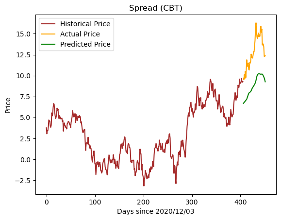

```python
plt.plot(np.arange(0, len(y_train_cbt)), scaler.inverse_transform(y_train_cbt), color='brown', label='Historical Price')
plt.plot(np.arange(len(y_train_cbt), len(y_train_cbt) + len(y_test_orig_cbt)), y_test_orig_cbt, color='orange', label='Actual Price')
plt.plot(np.arange(len(y_train_cbt), len(y_train_cbt) + len(y_pred_orig_cbt)), y_pred_orig_cbt, color='green', label='Predicted Price')

plt.title('Spread (CBT)')
plt.xlabel('Days since 2020/12/03')
plt.ylabel('Price')
plt.legend()
plt.show();
```

```python
print('Mean square error for CBT Spread forecast is ', mean_squared_error(y_test_orig_cbt, y_pred_orig_cbt))
print('R squared score for CBT Spread forecast is ',r2_score(y_test_orig_cbt, y_pred_orig_cbt))
```

```
Mean square error for CBT Spread forecast is  17.42251261623121
R squared score for CBT Spread forecast is  -3.760857275716253
```

```python
print('Mean square error for ICE Spread forecast is ', mean_squared_error(y_test_orig_ice, y_pred_orig_ice))
print('R squared score for ICE Spread forecast is ', r2_score(y_test_orig_ice, y_pred_orig_ice))
```

```
Mean square error for ICE Spread forecast is  6.3176107056806625
R squared score for ICE Spread forecast is  -0.6969557877873589
```

High mean squared error and low R-squared scores show that there could be improvement when it comes to model selection and although LSTM catch the overall trend of time-series, there are nuances that weren't considered in the training process.